# hw1_part3_electricity

### Modeling Daily Electricity Generation (MWh)

TP ELEKTUKETIM URT

```python
import pandas as pd

data_path = "C:\\Users\\EylülRanaSaraç\\OneDrive - boun.edu.tr\\Masaüstü\\IE 360\\hw1\\electricity.csv"

df = pd.read_csv(data_path, delimiter=';', decimal=',', na_values=';;')

# save the Date column and delete it from the df
date_series = df['Date']
df = df.drop('Date', axis=1)

for column in df.columns:
    if df[column].dtype == 'object':  # controls the string data type
        df[column] = df[column].str.replace('.', '').str.replace(',', '.').astype(float)

# add the Date column again to the first column
df.insert(0, 'Date', date_series)

# delete the rows with all NaN values
df.dropna(how='all', inplace=True)

df.head()
```

|  | Date | TP ELEKTUKETIM URT | TP ELEKTUKETIM IHR | TP ELEKTUKETIM ITH | TP FG J0 | TP FG J04 | TP FG J045 | TP FG C03 | TP FG C07 | TP KKHARTUT KT1 | ... | TP FG J125 | TP HKFE01 | TP GY1 N2 | TP IYAW2 S01 A | TP AB B2 | TP DT IH FIY D01 2010 | TP KB GEN01 | TP CLI2 A01 | TP IN KL1 APT DEV A | TP KKO2 IS TOP |
| --- | --- | --- | --- | --- | --- | --- | --- | --- | --- | --- | --- | --- | --- | --- | --- | --- | --- | --- | --- | --- | --- |
| 0 | 2016-01 | 748704.51 | 6091.00 | 22731.10 | 274.44 | 312.53 | 311.04 | 38330269.7 | 280793577.4 | 53014391.0 | ... | 423.08 | 85.7 | 103.2 | 34.0 | 92878.0 | 94.02 | 45549807.0 | 267.22 | 51.0 | 77.2 |
| 1 | 2016-02 | 713037.70 | 3945.77 | 20327.56 | 274.38 | 313.65 | 310.65 | 38441274.2 | 279078087.4 | 43982515.0 | ... | 438.77 | 86.6 | 104.6 | 18.5 | 93740.0 | 94.62 | 42505869.0 | 267.33 | 127.0 | 76.0 |
| 2 | 2016-03 | 701978.16 | 1953.29 | 14832.61 | 274.27 | 314.16 | 310.11 | 38311290.7 | 281225312.7 | 45159520.0 | ... | 449.65 | 87.5 | 107.2 | 19.7 | 95718.0 | 94.52 | 38751806.0 | 269.05 | 54.0 | 76.2 |
| 3 | 2016-04 | 700531.35 | 3592.09 | 13121.53 | 276.42 | 315.33 | 309.75 | 38236357.3 | 290007463.3 | 58310084.0 | ... | 464.23 | 88.6 | 110.5 | 25.2 | 96199.0 | 95.60 | 48722117.0 | 272.01 | 139.0 | 77.0 |
| 4 | 2016-05 | 695620.44 | 1898.07 | 12739.00 | 278.02 | 316.53 | 309.65 | 39020835.6 | 294497954.1 | 47603465.0 | ... | 467.61 | 89.7 | 110.2 | 28.1 | 98037.2 | 96.04 | 47733499.0 | 273.43 | 131.0 | 77.7 |

5 rows × 42 columns

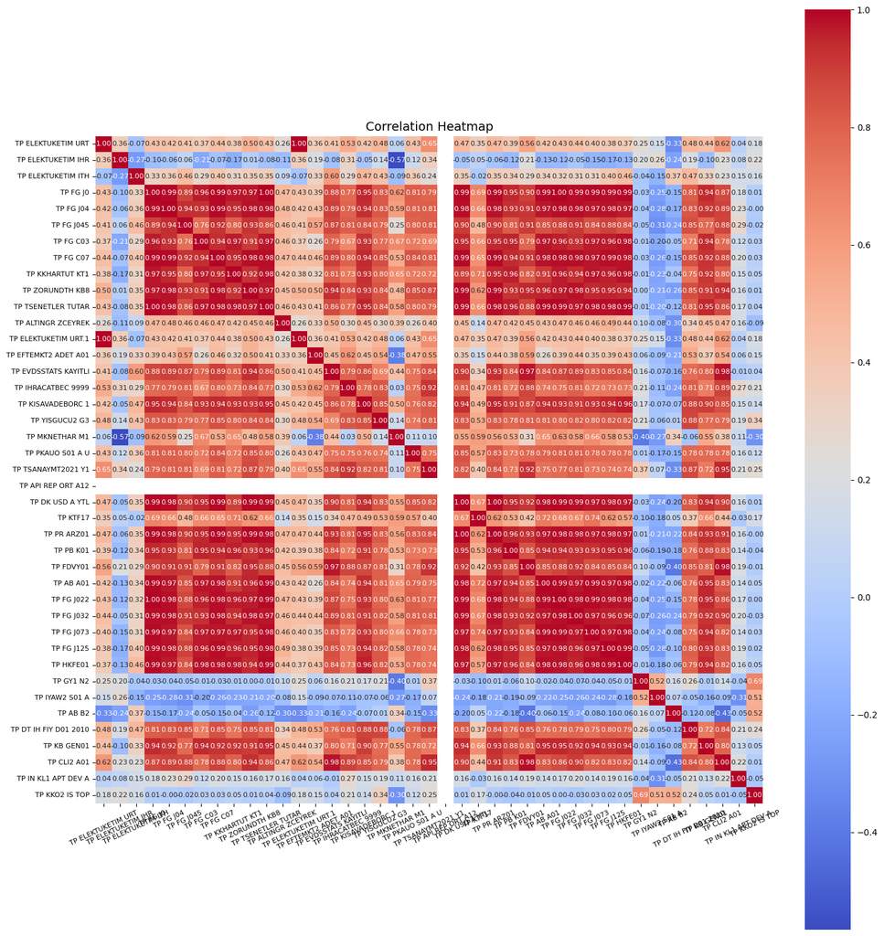

```python
import matplotlib.pyplot as plt
import seaborn as sns

df['Date'] = pd.to_datetime(df['Date'])

# Set the date column as the index
df.set_index('Date', inplace=True)

# Calculate the correlation matrix
correlation_matrix = df.corr()

plt.figure(figsize=(15, 15))

# draw the heatmap
ax = sns.heatmap(correlation_matrix, annot=True, cmap='coolwarm', fmt=".2f",
                 annot_kws={'size': 8}, square=True)

plt.xticks(fontsize=8, rotation=25)
plt.yticks(fontsize=8, rotation=0)
plt.title('Correlation Heatmap', fontsize=14)
plt.tight_layout()

plt.show()
```

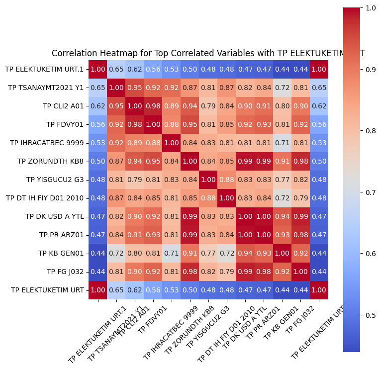

```python
# FINDING HIGH CORRELATED DATA WITH 'TP ELEKTUKETIM URT'

target_correlations = correlation_matrix['TP ELEKTUKETIM URT'].drop('TP ELEKTUKETIM URT')

sorted_correlations = target_correlations.abs().sort_values(ascending=False)

top_variables = sorted_correlations.head(12).index.tolist()

top_variables.append('TP ELEKTUKETIM URT')

filtered_corr_matrix = correlation_matrix.loc[top_variables, top_variables]

plt.figure(figsize=(8, 8))

ax = sns.heatmap(filtered_corr_matrix, annot=True, cmap='coolwarm', fmt=".2f",
                 annot_kws={'size': 10}, square=True)

plt.xticks(fontsize=10, rotation=45)
plt.yticks(fontsize=10, rotation=0)
plt.title('Correlation Heatmap for Top Correlated Variables with TP ELEKTUKETIM URT', fontsize=12)
plt.tight_layout()

plt.show()
```

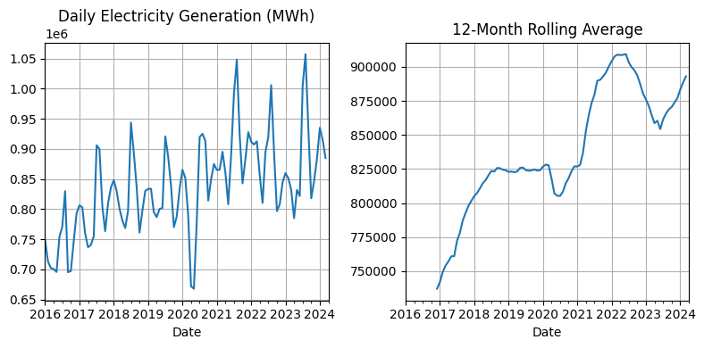

```python
import matplotlib.pyplot as plt

fig, ax = plt.subplots(nrows=1, ncols=2, figsize=(8, 4))

# 1. line plot
df['TP ELEKTUKETIM URT'].plot(ax=ax[0])
ax[0].set_title('Daily Electricity Generation (MWh)')
ax[0].grid(True)

# 2. 12-Month Rolling Average
df['TP ELEKTUKETIM URT'].rolling(window=12).mean().plot(ax=ax[1])
ax[1].set_title('12-Month Rolling Average')
ax[1].grid(True)

plt.tight_layout()
plt.show()
```

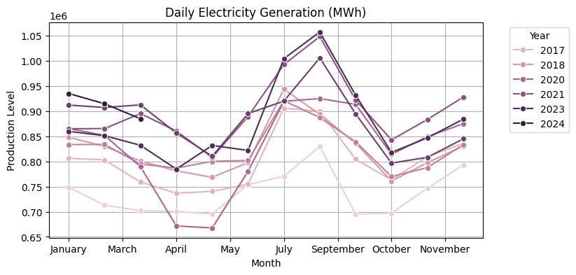

```python
from matplotlib.ticker import MaxNLocator

df['Month'] = df.index.month_name()
df['Year'] = df.index.year

plt.figure(figsize=(8, 4))
sns.lineplot(x="Month", y="TP ELEKTUKETIM URT", hue="Year", data=df, marker='o')

plt.title('Daily Electricity Generation (MWh)')
plt.ylabel('Production Level')
plt.legend(title='Year', bbox_to_anchor=(1.05, 1), loc='upper left')
plt.grid(True)
plt.gca().xaxis.set_major_locator(MaxNLocator(nbins=12))

plt.show()
```

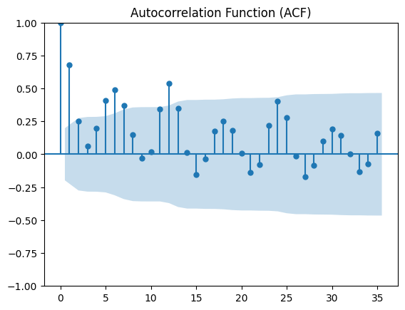

```python
from statsmodels.graphics.tsaplots import plot_acf, plot_pacf
import matplotlib.pyplot as plt

plt.figure(figsize=(10, 3))
plot_acf(df['TP ELEKTUKETIM URT'], lags=35)
plt.title('Autocorrelation Function (ACF)')

plt.show()
```

[figure not shown]

```python
# PACF
plt.figure(figsize=(10, 3))
plot_acf(df['TP ELEKTUKETIM URT'], lags=35)
plt.title('Partial Autocorrelation Function (PACF)')
plt.show()
```

There is seasonality.

### Introducing Independent Variables

1. TP CLI2 A01 - Composite Leading Indicators Index

It makes sense to model daily electricity generation with the Composite Leading Indicators Index, an indicator of economic activity, and the Fuel and Energy Price Index, which reflects energy costs. This is because as the economy grows, factories and businesses work harder, which means more electricity consumption. This implies that demand for electricity generation will increase.

On the other hand, changes in energy prices directly affect electricity generation costs. If energy prices go up, electricity generation costs go up; if prices go down, costs go down. On the other hand, an increase in the price of electricity can also increase earnings. Therefore, these two factors are closely interrelated. Considering these two factors together allows us to better understand the economic and cost impacts on electricity generation.

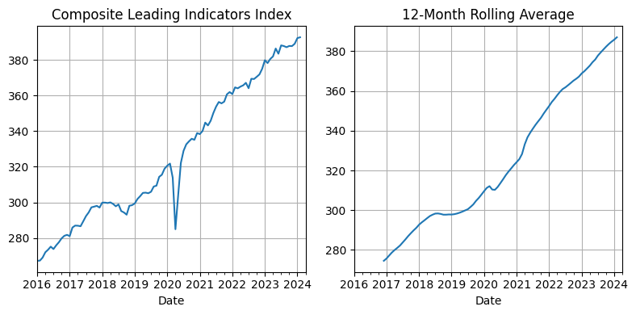

```python
fig, ax = plt.subplots(nrows=1, ncols=2, figsize=(8, 4))

# 1. line plot
df['TP CLI2 A01'].plot(ax=ax[0])
ax[0].set_title('Composite Leading Indicators Index')
ax[0].grid(True)

# 2. 12-Month Rolling Average
df['TP CLI2 A01'].rolling(window=12).mean().plot(ax=ax[1])
ax[1].set_title('12-Month Rolling Average')
ax[1].grid(True)

plt.tight_layout()
plt.show()
```

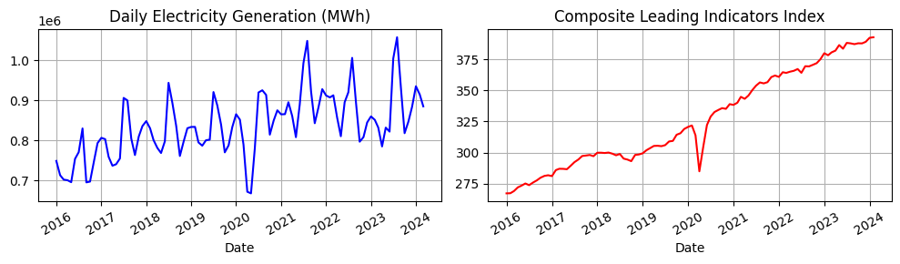

```python
# Comparing Total Industry and Daily Electricity Generation (MWh) data
fig, axes = plt.subplots(nrows=1, ncols=2, figsize=(10, 3))

# 1st subplot
axes[0].plot(df.index, df['TP ELEKTUKETIM URT'], label='Number of Payment Messages', color='blue')
axes[0].set_title('Daily Electricity Generation (MWh)')
axes[0].set_xlabel('Date')
axes[0].grid(True)

# 2nd subplot
axes[1].plot(df.index, df['TP CLI2 A01'], label='Total Industry', color='red')
axes[1].set_title('Composite Leading Indicators Index')
axes[1].set_xlabel('Date')
axes[1].grid(True)

for ax in axes:
    plt.sca(ax)
    plt.xticks(rotation=30)

plt.tight_layout()
plt.show()
```

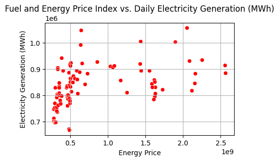

```python
plt.figure(figsize=(5, 3))
sns.scatterplot(x='TP FG C07', y='TP ELEKTUKETIM URT', data=df, color='red')
plt.title('Fuel and Energy Price Index vs. Daily Electricity Generation (MWh)')
plt.xlabel('Energy Price')
plt.ylabel('Electricity Generation (MWh)')
plt.grid(True)
plt.show()
```

### Model

[output not shown]

[figure not shown]

```python
from sklearn.model_selection import train_test_split
from sklearn.linear_model import LinearRegression
from sklearn.metrics import mean_squared_error, r2_score

df.dropna(subset=['TP CLI2 A01'], inplace=True)

# indepentent variable
X = df[['TP CLI2 A01']].values

# depentent variable
y = df['TP ELEKTUKETIM URT'].values

# creating test and train sets
X_train, X_test, y_train, y_test = train_test_split(X, y, test_size=0.3, random_state=0)

# Training the model
model = LinearRegression()
model.fit(X_train, y_train)

# making predictions
y_pred = model.predict(X_test)

# evaluating the model performance
print(f"R^2 Score: ", r2_score(y_test, y_pred))
print("Mean Squared Error (MSE):", mean_squared_error(y_test, y_pred))
print(f"Number of Payment Messages = {model.intercept_} + {model.coef_} * (RUB/TRY) ")

plt.figure(figsize=(6, 3))
plt.scatter(X_test, y_test, color='purple', label='Real Values')
plt.plot(X_test, y_pred, color='orange', linewidth=2, label='Predictions')
plt.title('Model Predictions vs Real Values')
plt.xlabel('Total Industry')
plt.ylabel('Number of Payment Messages')
plt.legend()
plt.show()
```

This is not a successful model because we did not include seasonality.

Introduce Other Independent Variables

```python
# variables
X = df[['TP CLI2 A01', 'TP FG C07']].values
y = df['TP ELEKTUKETIM URT'].values

X_train, X_test, y_train, y_test = train_test_split(X, y, test_size=0.3, random_state=0)

model = LinearRegression()
model.fit(X_train, y_train)

y_pred = model.predict(X_test)

print(f"R^2 Score: ", r2_score(y_test, y_pred))
print("Mean Squared Error (MSE):", mean_squared_error(y_test, y_pred))
```

```
R^2 Score:  0.49294760582009434
Mean Squared Error (MSE): 3439954531.0340447
```

Adding the second variable did not improve the model enough. We need to add seasonality.

### Conclusion

In this analysis, three target variables, namely the dollar exchange rate, daily electricity generation and the number of payment messages, are modeled with regression models using various independent variables. The choice of these independent variables is supported by economic logic.

Modeling daily electricity generation with economic activity indicators and energy costs highlights the sensitivity of electricity consumption to economic growth and energy prices. In particular, the ability to model the dollar exchange rate well with a single variable such as the ruble exchange rate in a simple model demonstrates the power of these tools.

In conclusion, this analysis demonstrated the power of regression modeling with time series data and illuminated the relationships between economic events and financial indicators. However, it is important to be aware of the limitations of each model and to be cautious when interpreting the model results.